# Group18_HeartDataset

Group Number: 18  
Group Members:

1. Ashwini Kumar Saurabh (Roll No: 2021c104011)
2. Arya Banerjee (Roll No: 2021c104010)
3. Rishabh Chowdhury (Roll No: 2021c104023)

Assignment Dataset: Heart Disease Prediction

https://drive.google.com/file/d/1vkJC36xZJ9oaCLp1Q1Sp3ctXgqaxyQzN/view?usp=sharing

```python
data_path=r'heart (1).csv'
```

## 1. Import Libraries/Dataset

```python
# Libraries
import pandas as pd
import numpy as np
import pandas as pd
pd.set_option("display.max_columns", 101)
pd.set_option('display.expand_frame_repr', False)
pd.options.display.max_colwidth=1000

import matplotlib
import matplotlib.pyplot as plt
import seaborn as sns

#import matplotlib.ticker as ticker

#from collections import defaultdict
from sklearn import preprocessing
from sklearn.decomposition import PCA

from sklearn.model_selection import train_test_split
from sklearn import ensemble
from sklearn import metrics
from sklearn import model_selection

from sklearn.neighbors import KNeighborsClassifier
from sklearn.tree import DecisionTreeClassifier
from sklearn.metrics import f1_score, confusion_matrix
```

```python
df=pd.read_csv(data_path)
print(df.shape)
```

```
(1025, 14)
```

## 2 Data Visualization and Exploration

### 2.1 Print 2 rows for sanity check to identify all the features present in the dataset and if the target matches with them.

```python
print(df.head(2))
```

```
   age  sex  cp  trestbps  chol  fbs  restecg  thalach  exang  oldpeak  slope  ca  thal  target
0   52    1   0       125   212    0        1      168      0      1.0      2   2     3       0
1   53    1   0       140   203    1        0      155      1      3.1      0   0     3       0
```

### 2.2 Comment on class imbalance with appropriate visualization method.

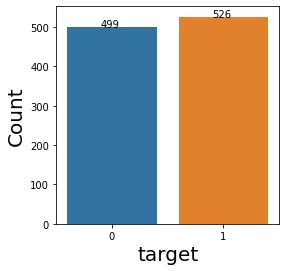

```python
# Distribution of target class
plt.rcParams["figure.figsize"] = [4, 4]
ax = sns.countplot(x='target', data = df)

for p in ax.patches:
   ax.annotate('{:}'.format(p.get_height()), (p.get_x()+0.3, p.get_height()))

ax.set_xlabel("target", fontsize=20)
ax.set_ylabel("Count", fontsize=20)

plt.show()
```

Target 0(ie.No Heart Disease) have 499 records and 1(ie. Heart Disease) have 526 records. Data is balanced.

### 2.3 Provide appropriate visualizations to get an insight about the dataset.

```python
# Identify columns having categorical values
#Columns  index and enrollee_id are not categorical column. Analyse remaining columns
for i, val in enumerate(list(df.columns)):
    print('\n\n')
    print (val)
    print(df.groupby([val], dropna=False, as_index=False).size().head(10))
```

```
age
   age  size
0   29     4
1   34     6
2   35    15
3   37     6
4   38    12
5   39    14
6   40    11
7   41    32
8   42    26
9   43    26



sex
   sex  size
0    0   312
1    1   713



cp
   cp  size
0   0   497
1   1   167
2   2   284
3   3    77



trestbps
   trestbps  size
0        94     7
1       100    14
2       101     3
3       102     6
4       104     3
5       105     9
6       106     3
```

[output cut: 89 more lines]

```


thal
   thal  size
0     0     7
1     1    64
2     2   544
3     3   410



target
   target  size
0       0   499
1       1   526
```

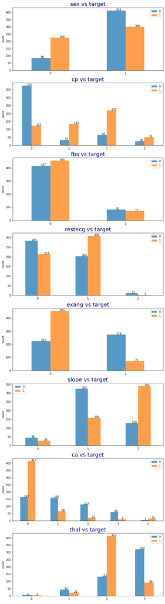

```python
# check how all categorical  features are distributed.

cat_cols= ['sex','cp','fbs','restecg','exang','slope','ca','thal']

plt.figure(figsize=(10,len(cat_cols)*5))

for i,val in enumerate(cat_cols):
  #print( i.__str__() +'  ' + val)
  plt.subplot(len(cat_cols), 1, i+1)
  df_plot= df.groupby([val,'target'])["target"].count().reset_index(name="count")
  df_plot=df_plot.round(decimals = 2)
  df_plot=df_plot.pivot(val, "target", "count")
  df_plot.reset_index(inplace=True)
  ax=df_plot.plot(x=val, y=[0, 1], kind="bar",logy=False,logx=False,ax=plt.gca(),fontsize = 10,alpha=0.75, rot=10,sort_columns = True)
  for p in ax.patches:
    ax.annotate('{:}'.format(p.get_height()), (p.get_x()+p.get_width()/2, p.get_height()))
  plt.title( val +' vs target',fontsize = 20, color='Navy')
  plt.legend(fontsize = 10)
  plt.xlabel(val,fontsize = 0)
  plt.ylabel('count',fontsize = 10)
```

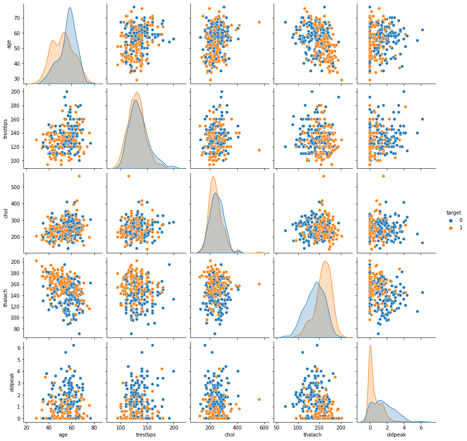

```python
# check how all continuous features are distributed.
cont_cols= ['age','trestbps','chol','thalach','oldpeak','target']
sns.pairplot(df[cont_cols], hue ='target')
# to show
plt.show()
```

### 2.4 Do the correlational analysis on the dataset. Provide a visualization for the same. Will this correlational analysis have effect on feature selection that you will perform in the next step? Justify your answer

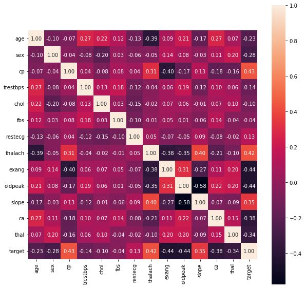

```python
cols=list(df.columns)
plt.figure(figsize=(10,10))
cm = np.corrcoef(df[cols].values.T)

hm = sns.heatmap(cm,
                 cbar=True,
                 annot=True,
                 square=True,
                 fmt='.2f',
                 annot_kws={'size': 10},
                 yticklabels=cols,
                 xticklabels=cols)

plt.show()
```

We can observe that features are not highly correlated among each other. We don't have any feature with correlation above 0.9 with another feature. So these all features can be considered to train machine learning models.

## 3 Data Pre-processing and cleaning

### 3.1 Do the appropriate pre-processing of the data like identifying NULL or Missing Values if any, handling of outliers if present in the dataset, skewed data etc. Mention the pre-processing steps performed in the markdown cell.Explore a few latest data balancing tasks and its effect on model evaluation parameters.

Check if we have any null value in attributes.

```python
df.isna().sum()
```

```
age         0
sex         0
cp          0
trestbps    0
chol        0
fbs         0
restecg     0
thalach     0
exang       0
oldpeak     0
slope       0
ca          0
thal        0
target      0
dtype: int64
```

Note: We don't have any attribute with null values

We observed by dropping of duplicate records the performance of model degraded on test data. So we will not be dropping duplicate records.

### 3.2. Apply appropriate feature engineering techniques for them. Apply the feature transformation techniques like Standardization, Normalization, etc. You are free to apply the appropriate transformations depending upon the structure and the complexity of your dataset. Provide proper justification.

#### 3.2.1 Scale the column values using MinMaxScaler or StandardScaler

```python
scaler = preprocessing.MinMaxScaler()
features=list(df.columns)
features.remove('target')
#print(df.head())
for i, column in enumerate(features):

  df[[column]]=scaler.fit_transform(df[[column]])

print(df.head())
```

```
        age  sex   cp  trestbps      chol  fbs  restecg   thalach  exang   oldpeak  slope    ca      thal  target
0  0.479167  1.0  0.0  0.292453  0.196347  0.0      0.5  0.740458    0.0  0.161290    1.0  0.50  1.000000       0
1  0.500000  1.0  0.0  0.433962  0.175799  1.0      0.0  0.641221    1.0  0.500000    0.0  0.00  1.000000       0
2  0.854167  1.0  0.0  0.481132  0.109589  0.0      0.5  0.412214    1.0  0.419355    0.0  0.00  1.000000       0
3  0.666667  1.0  0.0  0.509434  0.175799  0.0      0.5  0.687023    0.0  0.000000    1.0  0.25  1.000000       0
4  0.687500  0.0  0.0  0.415094  0.383562  1.0      0.5  0.267176    0.0  0.306452    0.5  0.75  0.666667       0
```

#### 3.2.2 Feature Engineering Technique - Chi Square

Since the data set comprises of categorical values, have used the chi square test. The chi-square value is calculated between each attribute and the target variable, and the attributes with the best chi-square value is selected.

```python
from sklearn.feature_selection import SelectKBest
from sklearn.feature_selection import chi2

features=list(df.columns)
features.remove('target')

x = df.loc[:, features].values
# Separating out the target
y = df.loc[:,['target']].values

# Standardizing the features

chi_scores = chi2(x,y)
```

```python
df_chi=pd.DataFrame(chi_scores)
df_chi.columns=features
df_chi_scores=df_chi.transpose()
df_chi_scores['features'] = df_chi_scores.index
df_chi_scores.columns=['Chi_Square', 'P_Value','Features']
df_chi_scores = df_chi_scores.reset_index(drop=True)
df_chi_scores= df_chi_scores.sort_values('P_Value')
print(df_chi_scores)
```

```
    Chi_Square       P_Value  Features
8   130.470927  3.232318e-30     exang
2    72.607974  1.581388e-17        cp
11   52.656480  3.972979e-13        ca
9    40.911849  1.592527e-10   oldpeak
1    24.373650  7.934661e-07       sex
10   16.836974  4.073193e-05     slope
7     9.471895  2.086437e-03   thalach
12    6.457822  1.104650e-02      thal
6     4.869671  2.733271e-02   restecg
0     3.630553  5.672798e-02       age
3     1.517674  2.179718e-01  trestbps
5     1.477550  2.241583e-01       fbs
4     0.518226  4.715995e-01      chol
```

[figure not shown]

```python
fig = plt.figure(figsize=(12,4))

ax = fig.add_subplot(111)
ax.set_xticklabels(ax.get_xticklabels(),rotation = 60)
sns.barplot(x=features, y='P_Value', data=df_chi_scores, ax=ax)
plt.show()
```

3.2.3 Feature Engineering --Random Forest Classifier

Random forest classifier techinique uses multiple decision trees and merges them together to form a precise and stable prediction for a larger data set.

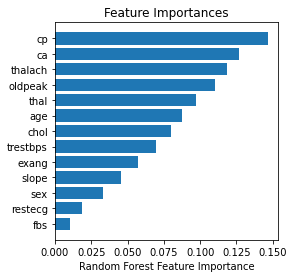

```python
#Check feature importance
from sklearn import ensemble
import matplotlib.pyplot as plt
import numpy as np

##Get list of features which will be used to predict 'subs_deposit'.
featured_cols= list(df.columns)
col_names= featured_cols
col_names.remove('target')


##Use model RandomForestRegressor to see feature importance to predict target 'subs_deposit'
model=ensemble.RandomForestClassifier()
#fit the model with train data
model.fit(df[col_names],df['target'])
importances = model.feature_importances_
idxs = np.argsort(importances)
plt.title("Feature Importances")
plt.barh(range(len(idxs)), importances[idxs], align='center')
plt.yticks(range(len(idxs)), [col_names[i] for i in idxs])
plt.xlabel("Random Forest Feature Importance")
plt.show()
```

As per Random forest, important features are 'cp','ca','oldpeak','thalach','thal','age','chol','trestbps','exang','slope'

```python
features=list(df.columns)
features.remove('target')

x = df.loc[:, features].values
# Separating out the target
y = df.loc[:,['target']].values

# Perform dimension reduction by PCA and project it to 2 dimensions.
pca = PCA(n_components=2)
principalComponents = pca.fit_transform(x)
principalDf = pd.DataFrame(data = principalComponents
             , columns = ['pc1', 'pc2'])
finalDf = pd.concat([principalDf, df.target],axis=1)
print(finalDf.head())
```

```
        pc1       pc2  target
0 -0.095116 -0.390900       0
1  1.007104  0.051511       0
2  0.965295  0.115793       0
3 -0.128527 -0.366660       0
4 -0.197045  0.663817       0
```

```python
print(pca.components_)
```

```
[[ 0.04883085  0.37138296 -0.35298915  0.01961923  0.00589247  0.05140101
  -0.06254313 -0.15543084  0.77198259  0.15574781 -0.23548982  0.11954915
   0.1182999 ]
 [ 0.08544567 -0.91412421 -0.19471117  0.04646443  0.06377852 -0.01912411
   0.00719039 -0.07790799  0.28699838  0.05592408 -0.13580504 -0.01721718
  -0.04706151]]
```

```python
print(pca.explained_variance_)
```

```
[0.29861425 0.20295892]
```

```python
# Reformat and view results
fe_df_columns=list(df.columns)
fe_df_columns.remove('target')
df_pca = pd.DataFrame(pca.components_.T,
columns=['PC%s' % _ for _ in range(len(principalDf.columns))],
index=fe_df_columns)
#df_pca['Features'] = df_pca.index
df_pca.reset_index(inplace = True)
df_pca.columns=['Features','PC_1','PC_2']
print(df_pca)
```

```
    Features      PC_1      PC_2
0        age  0.048831  0.085446
1        sex  0.371383 -0.914124
2         cp -0.352989 -0.194711
3   trestbps  0.019619  0.046464
4       chol  0.005892  0.063779
5        fbs  0.051401 -0.019124
6    restecg -0.062543  0.007190
7    thalach -0.155431 -0.077908
8      exang  0.771983  0.286998
9    oldpeak  0.155748  0.055924
10     slope -0.235490 -0.135805
11        ca  0.119549 -0.017217
12      thal  0.118300 -0.047062
```

important features are 'exang', 'sex','cp',

## 4 Model Building

```python
chi_imp_features=['age','sex','cp','trestbps','chol','fbs','restecg','thalach','exang']
random_forest_imp_features=['cp','ca','oldpeak','thalach','thal','age','chol','trestbps','exang','slope']
imp_features=chi_imp_features
print('Important Features are :\n')
print(imp_features)
imp_features.append('target')
data_df=df[imp_features]
data_df.head(2)
```

```
Important Features are :

['age', 'sex', 'cp', 'trestbps', 'chol', 'fbs', 'restecg', 'thalach', 'exang']
```

|  | age | sex | cp | trestbps | chol | fbs | restecg | thalach | exang | target |
| --- | --- | --- | --- | --- | --- | --- | --- | --- | --- | --- |
| 0 | 0.479167 | 1.0 | 0.0 | 0.292453 | 0.196347 | 0.0 | 0.5 | 0.740458 | 0.0 | 0 |
| 1 | 0.500000 | 1.0 | 0.0 | 0.433962 | 0.175799 | 1.0 | 0.0 | 0.641221 | 1.0 | 0 |

We have observed that important features obtained from Chi Square and Random forest are giving similar performance. We can pick up features from either Chi-square or Random Forest.

#### 4.1 Split the dataset into training and test sets. Justify your choice of split. You may experiment with different split to get the final split

We have taken train/test split as 80/20 and 60/40.  
The higher training data set percentage gives more accurate results.  
We observed that the higher percentage of training data (70-80%) gives a more accurate result.

Split1--> 80:20 split. 80% of data will be used for training and 20% of data will be used for testing.

```python
imp_features.remove('target')
x = data_df.loc[:, imp_features].values
# Separating out the target
y = data_df.loc[:,['target']].values

x_train, x_test, y_train, y_test = train_test_split(x, y, stratify=y,random_state=42, test_size=0.20)
print(x_train.shape, y_train.shape, x_test.shape, y_test.shape)
```

```
(820, 9) (820, 1) (205, 9) (205, 1)
```

Split 2--> 60:40 split. 60% of data will be used for training and 40% of data will be used for testing.

```python
x_train2, x_test2, y_train2, y_test2 = train_test_split(x, y, stratify=y,random_state=42, test_size=0.40)
print(x_train2.shape, y_train2.shape, x_test2.shape, y_test2.shape)
```

```
(615, 9) (615, 1) (410, 9) (410, 1)
```

#### 4.2 Machine Learning Model: KNN (Test Size : 20%)

```python
classifier = KNeighborsClassifier()

k_range = list(range(1, 31))
param_grid = dict(n_neighbors=k_range)

#initialize grid serach
model=model_selection.GridSearchCV(
    estimator=classifier,
    param_grid=param_grid,
    scoring="accuracy",
    verbose=1,
    n_jobs=1,
    cv=5
)

#fit the model

model.fit(x_train, y_train.ravel())
print(f"Best score: {model.best_score_}")
print("Best Parameter set:")
best_parameters=model.best_estimator_.get_params()
for param_name in sorted(param_grid.keys()):
  print(f"\t {param_name}: {best_parameters[param_name]}")
```

```
Fitting 5 folds for each of 30 candidates, totalling 150 fits
Best score: 0.974390243902439
Best Parameter set:
	 n_neighbors: 1
```

```python
best_model = model.best_estimator_
best_model.fit(x_train, y_train.ravel())
preds=best_model.predict(x_test)

#print("F1 score: {:.3f}".format(f1_score(y_test, preds)))
print("Accuracy score: {:.3f}".format(metrics.accuracy_score(y_test, preds)))
print('Confusion Matrix:')
print(confusion_matrix(y_test, preds))
```

```
Accuracy score: 1.000
Confusion Matrix:
[[100   0]
 [  0 105]]
```

#### 4.3 Machine Learning Model: KNN (Test Size : 40%)

```python
classifier = KNeighborsClassifier()

k_range = list(range(1, 31))
param_grid = dict(n_neighbors=k_range)

#initialize grid serach
model=model_selection.GridSearchCV(
    estimator=classifier,
    param_grid=param_grid,
    scoring="accuracy",
    verbose=1,
    n_jobs=1,
    cv=5
)

#fit the model

model.fit(x_train2, y_train2.ravel())
print(f"Best score: {model.best_score_}")
print("Best Parameter set:")
best_parameters=model.best_estimator_.get_params()
for param_name in sorted(param_grid.keys()):
  print(f"\t {param_name}: {best_parameters[param_name]}")
```

```
Fitting 5 folds for each of 30 candidates, totalling 150 fits
Best score: 0.9577235772357724
Best Parameter set:
	 n_neighbors: 1
```

```python
best_model = model.best_estimator_
best_model.fit(x_train2, y_train2.ravel())
preds=best_model.predict(x_test2)

#print("F1 score: {:.3f}".format(f1_score(y_test, preds)))
print("Accuracy score: {:.3f}".format(metrics.accuracy_score(y_test2, preds)))
print('Confusion Matrix:')
print(confusion_matrix(y_test2, preds))
```

```
Accuracy score: 0.954
Confusion Matrix:
[[190  10]
 [  9 201]]
```

#### 4.4 Machine Learning Model: Decision Tree Classifier (Test_size 20%)

```python
from sklearn.tree import DecisionTreeClassifier
classifier=DecisionTreeClassifier()
param_grid = {
    "min_samples_split" : range(2,10),
    "min_samples_leaf":range(2,5),
    "max_depth" : range(2,10),
    "criterion" :["gini","entropy"]
}

#initialize grid serach
model=model_selection.GridSearchCV(
    estimator=classifier,
    param_grid=param_grid,
    scoring="accuracy",
    verbose=1,
    n_jobs=1,
    cv=5
)
#fit the model

model.fit(x_train, y_train)
print(f"Best score: {model.best_score_}")
print("Best Parameter set:")
best_parameters=model.best_estimator_.get_params()
for param_name in sorted(param_grid.keys()):
  print(f"\t {param_name}: {best_parameters[param_name]}")
```

[output not shown]

```
Fitting 5 folds for each of 384 candidates, totalling 1920 fits
```

```python
best_model = model.best_estimator_
best_model.fit(x_train, y_train)
preds=best_model.predict(x_test)

#print("F1 score: {:.3f}".format(f1_score(y_test, preds)))
print("Accuracy score: {:.3f}".format(metrics.accuracy_score(y_test, preds)))
print('Confusion Matrix:')
print(confusion_matrix(y_test, preds))
```

[output not shown]

#### 4.5 Machine Learning Model: Decision Tree Classifier (Test_size 40%)

```python
classifier=DecisionTreeClassifier()
param_grid = {
    "min_samples_split" : range(2,10),
    "min_samples_leaf":range(2,5),
    "max_depth" : range(2,10),
    "criterion" :["gini","entropy"]
}

#initialize grid serach
model=model_selection.GridSearchCV(
    estimator=classifier,
    param_grid=param_grid,
    scoring="accuracy",
    verbose=1,
    n_jobs=1,
    cv=5
)
#fit the model

model.fit(x_train2, y_train2)
print(f"Best score: {model.best_score_}")
print("Best Parameter set:")
best_parameters=model.best_estimator_.get_params()
for param_name in sorted(param_grid.keys()):
  print(f"\t {param_name}: {best_parameters[param_name]}")
```

[output not shown]

```python
best_model = model.best_estimator_
best_model.fit(x_train2, y_train2)
preds=best_model.predict(x_test2)

#print("F1 score: {:.3f}".format(f1_score(y_test, preds)))
print("Accuracy score: {:.3f}".format(metrics.accuracy_score(y_test2, preds)))
print('Confusion Matrix:')
print(confusion_matrix(y_test2, preds))
```

[output not shown]

## 5.1 Performance Evaluation

[output not shown]

### 5.2 Conclusion:

Since we are getting best accuracy with KNN using case1 where model is trained on 80% dataset and 20% used for testing. We are getting accuracy of 100%, which is highest. KNN is the preferred model for this dataset. Train Test split of 80:20 is preferred.